# Data-Driven Exploration of Title V Facility Emissions in New York

A Work Sample

Bei Chu

# Introduction

This work sample presents an analysis of reported air pollutant emissions from Title V facilities across New York State. Title V facilities are major sources of air pollution that require operating permits under Title V of the U.S. Clean Air Act (USEPA, 2025a). In the state of New York, these permits are issued by the Department of Environmental Conservation and mandate that facilities report emissions of a number of regulated pollutants, including Carbon Dioxide (CO<sub>2</sub>), Carbon Monoxide (CO), Hazardous Air Pollutants (HAPs), Nitrogen Oxides (NO<sub>x</sub>), Particulates, PM10, PM2.5, Sulfur Dioxide (SO<sub>2</sub>), and Volatile Organic Compounds (VOCs) (NYSDEC, 2024, 2025).

The analysis includes visualizations of Title V facility locations and summary statistics of reported air emissions. Additionally, it features a focused analysis of HAPs, which are known to cause cancer and other serious health effects (USEPA, 2025b).

The HAPs analysis addresses the following key questions:  
1. What is the trend in HAPs emissions across New York State over time?  
2. Which industry sectors contribute most significantly to HAPs emissions?  
3. What are the spatial patterns of HAPs emissions in the state?

# Data Sources and Tools

This analysis draws from two publicly available datasets:

1. [Title V Emissions Inventory: Beginning 2010](https://data.ny.gov/Energy-Environment/Title-V-Emissions-Inventory-Beginning-2010/4ry5-tfin/about_data) - Annual reported emissions from Title V facilities across New York State
2. [Standard Industrial Classification Code Major Groups)](https://www.osha.gov/data/sic-manual) - Industry classification used to group facilities by sector

The report was prepared using R version 4.5.1 with R Markdown, leveraging a number of R packages for data wrangling, geospatial analysis, and visualization. The complete list of R packages and source code for this work can be found at https://github.com/beichu/NYS-Title-V-Facility-Emission.

# Results and Discussion

## Locations of Title V Facilities in New York

Two counties, Hamilton county and Otsego county, report no Title V facilities. Both counties contain large wilderness areas, have lower population density, and limited industrial development. The observed pattern highlights the importance of considering spatial distribution when making environmental policy and emission management strategies.

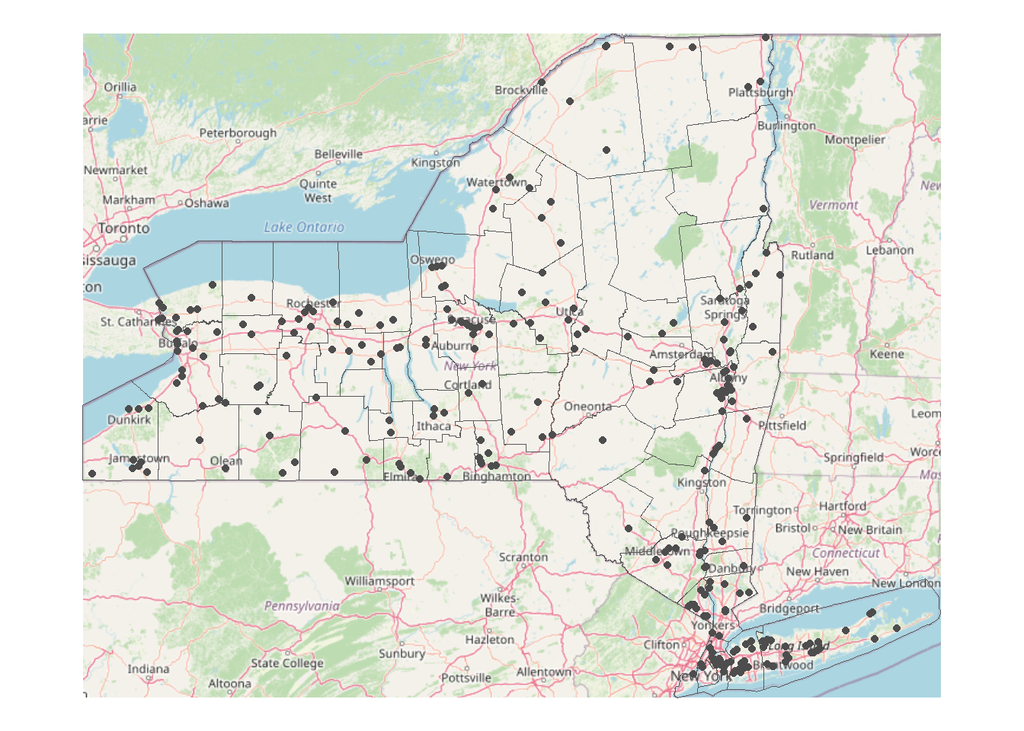

Figure 1: Title V Facility Locations in New York State

## Industry Composition of Title V Facilities

The Standard Industrial Classification (SIC) Manual published by the Occupational Safety and Health Administration (OSHA) categorizes industries into major groups based on their economic activities (OSHA, 2025). This classification system provides a structured framework for analyzing the types of facilities regulated under Title V. To better understand the industry distribution of Title V facilities, Table 1 summarizes the top industry sectors by facility count in New York State.

The electric, gas, and sanitary services includes 199 facilities and is the largest industry sector in New York based on the number of facilities. These facilities typically include power plants, natural gas distribution centers, and waste management operations, all of which potentially have large environmental impact.

Sectors ranked 2 through 10 each contain between 12 and 30 facilities and represent industries such as health services, chemical and allied products, real estate, and so on. All remaining sectors have 12 or fewer facilities.

Table 1: Top Industries in New York Based on the Number of Title V Facilities

| Industries | Number of Facilities |
| --- | --- |
| Electric, Gas, And Sanitary Services | 199 |
| Health Services | 30 |
| Chemicals And Allied Products | 28 |
| Real Estate | 27 |
| Wholesale Trade-non-durable Goods | 24 |
| Paper And Allied Products | 19 |
| Stone, Clay, Glass, And Concrete Products | 19 |
| Primary Metal Industries | 16 |
| Printing, Publishing, And Allied Industries | 16 |
| Educational Services | 12 |
| Other$^*$ | 106 |

* Other industries having 12 or less facilities

## Summary Statistics of Reported Emission Data

Table 2 presents summary statistics for each reported pollutant, including annual range, mean, median, and cumulative totals in New York across all available years. Carbon Dioxide (CO<sub>2</sub>) stands out with the highest cumulative emissions of 603,630,580 tons statewide. CO<sub>2</sub> also has the highest median annual value of 12,965 tons, indicating that CO<sub>2</sub> is a ubiquitous byproduct of industrial activities involving combustion.

In contrast, all other pollutants, including CO, NO<sub>x</sub>, SO<sub>2</sub>, Particulates, VOC, PM10, PM2.5, and HAPs, have median annual value of 13.7 tons or less. Despite their lower medians, several of these pollutants still show sizable cumulative totals, particularly CO and NO<sub>x</sub>, which are commonly associated with combustion and transportation (WHO, 2025).

For all nine pollutant categories, the median values are consistently lower than the corresponding means. This pattern suggests a right-skewed data distribution, where most facilities report relatively low emissions, while a small number of facilities report high emissions, thus significantly elevating the average.

Table 2: Summary Statisics of Title V Facility Air Emissions in New York State

| Analyte | Tons/Year Range | Tons/Year Mean | Tons/Year Median | Tons/Year Total |
| --- | --- | --- | --- | --- |
| CO | 0 - 21,241 | 99.9 | 8.34 | 533,157 |
| CO$_2$ | 0 - 4,505,945 | 113,061 | 12,965 | 603,630,580 |
| HAPs | 0 - 1,137 | 3.79 | 0 | 20,212 |
| NO$_x$ | 0 - 5,438 | 90.2 | 13.7 | 481,351 |
| PM10 | 0 - 1,771 | 7.95 | 0.17 | 42,449 |
| PM2.5 | 0 - 1,390 | 6.91 | 0.34 | 36,894 |
| Particulates | 0 - 5,796 | 18.6 | 1.7 | 99,515 |
| SO$_2$ | 0 - 13,380 | 74.6 | 0.34 | 398,087 |
| VOC | 0 - 910 | 17.3 | 5.13 | 92,390 |

## HAPs Emission Trends Across New York State Over Time

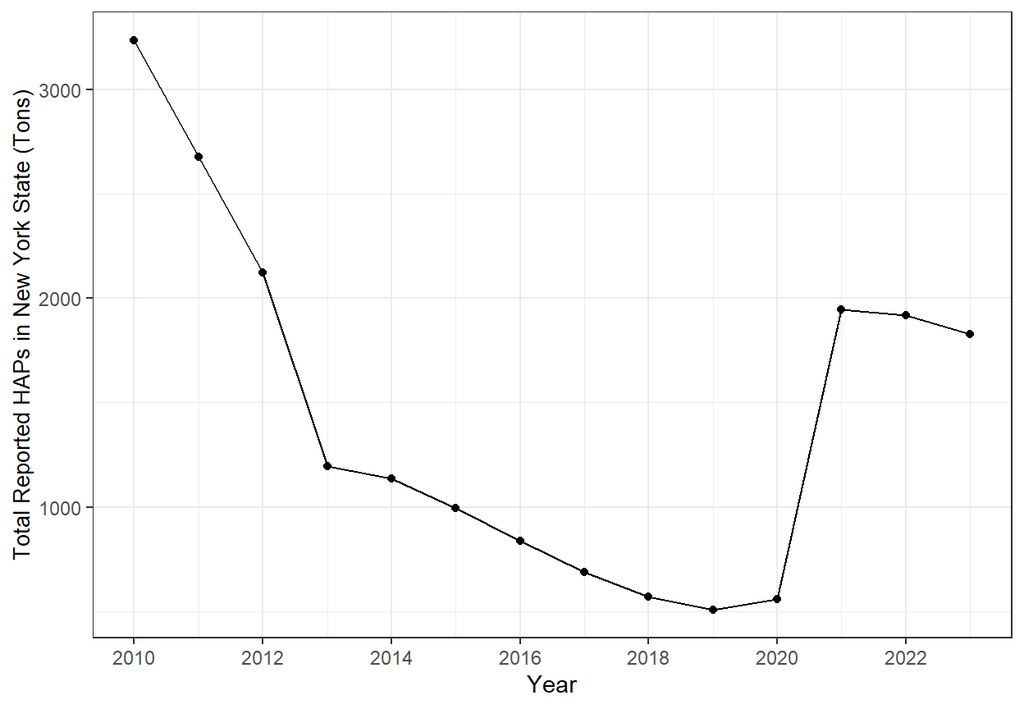

Figure 2: Reported HAPs Emission Over Time in New York State

## Top HAPs Emissions by Industry

As previously noted, Hazardous Air Pollutants (HAPs) pose significant risks to human health and were therefore selected for focused analysis in this report. Figure 3 highlights the top industry sectors contributing to total HAPs emissions from Title V facilities in New York State. The electric, gas, and sanitary services sector accounts for the largest share, contributing 48.2% of total reported HAPs emissions. This is followed by primary metal industries at 22.4%, and chemical and allied products industries at 8.8%. Together, these three sectors account for nearly 80% of all reported HAP emissions, showing the disproportionate impact of a few key sectors. It also provides insight for developing targeted regulatory and mitigation strategies for reducing HAPs emission.

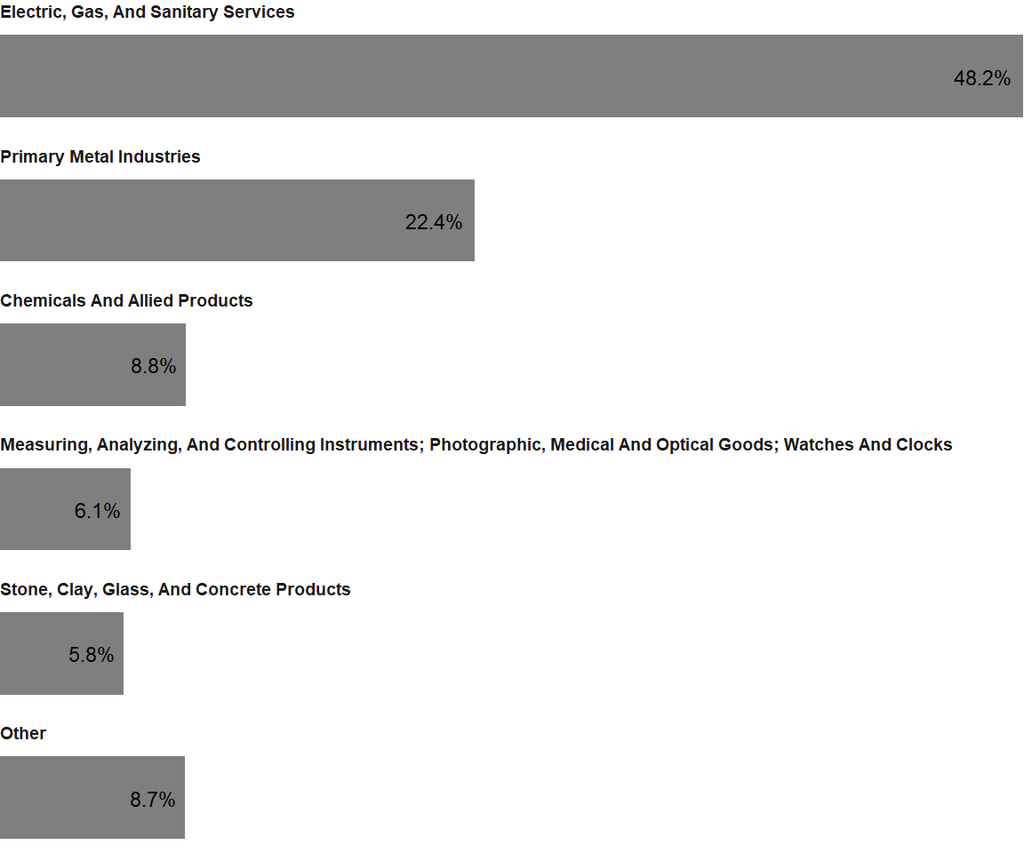

Figure 3: Breakdown of HAPs Emissions from Title V Facilities by Industry Sector in New York State.

## Average Annual HAPs Emission at the Individual Facility Level

To understand HAPs emission at the individual facility level, Figure 4 maps the average annual emissions across Title V facilities in New York State. Facilities are colored by emission intensity, with darker colors indicating higher average emissions. The majority of facilities emit 12 tons or less HAPs per year, reflecting a concentration of relatively low-emitting sources. This aligns with the previous finding in Table 2 that that median HAPs emission is 0 ton per year, indicating that half of the Title V facilities report no HAPs emission. However, a small number of facilities exceeds this threshold, with the highest reported HAPs value of 216 tons annually. This contrast shows a highly skewed distribution, where a few facilities contribute disproportionately to the overall HAPs emissions in the state. Again, the skewness in emission distribution highlights the importance of targeted HAPs regulatory and mitigation strategies on these high emission sources.

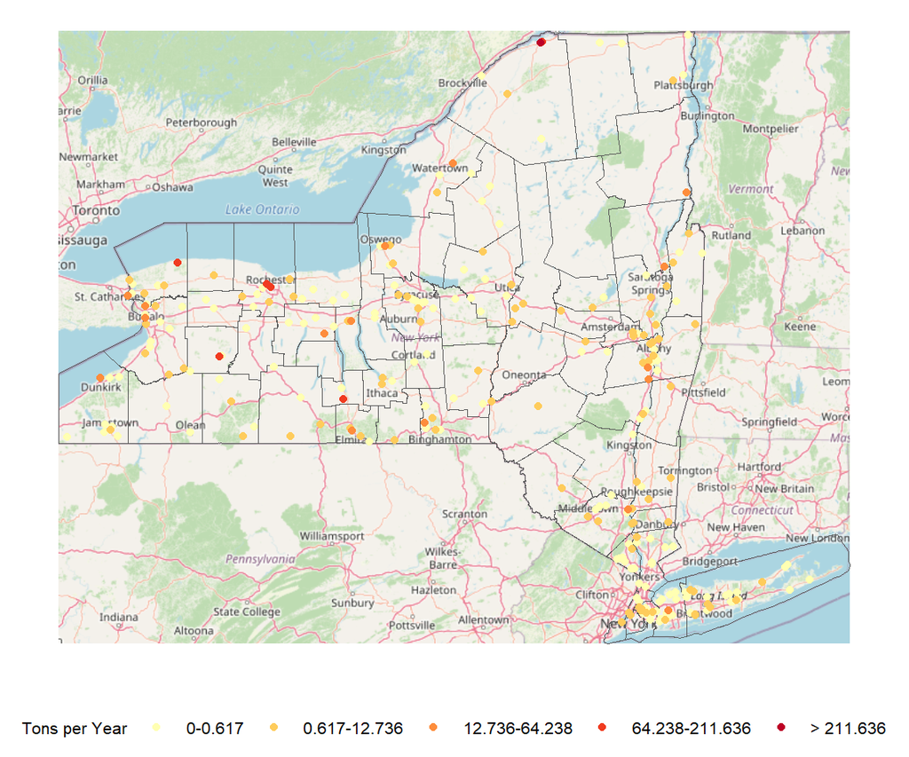

Figure 4: Average Annual HAPs Emission in New York Title V Facilities

# Conclusion

This analysis explores emissions data from Title V facilities across New York State. These facilities are geographically more concentrated around urban centers, contributing to elevated air pollution in those areas. The industry with the highest number of Title V facilities is electric, gas, and sanitary services. The top reported pollutants are CO<sub>2</sub>, CO, and NO<sub>x</sub>, indicating combustion related sources. While most facilities report relatively low annual HAPs emissions, a small number of high-emitting facilities and sectors, particularly the electric, gas, and sanitary services sector, contribute disproportionately to the statewide totals. The HAPs data displays a statistically significant decreasing trend over time. These findings promotes a targeted regulatory and sector or facility-specific mitigation approaches to reduce HAPs emissions and public health risks.

# References

NYSDEC. (2024). 2024 emissions statement instructions. Retrieved from https://dec.ny.gov/sites/default/files/2025-04/eim2024reprev.pdf

NYSDEC. (2025, October 4). Air compliance and emissions (ACE) reporting. Retrieved from https://dec.ny.gov/environmental-protection/air-quality/air-compliance-emissions-reporting

OSHA. (2025). Standard industrial classification (SIC) manual. Retrieved from https://www.osha.gov/data/sic-manual

USEPA. (2025b, October 4). Health and environmental effects of hazardous air pollutants. Retrieved from https://www.epa.gov/haps/health-and-environmental-effects-hazardous-air-pollutants

USEPA. (2025a, October 4). Who has to obtain a title v permit? Retrieved from https://www.epa.gov/title-v-operating-permits/who-has-obtain-title-v-permit

WHO. (2025). Air quality, energy and health. Retrieved from https://www.who.int/teams/environment-climate-change-and-health/air-quality-and-health/health-impacts/types-of-pollutants